# Reproducing the R Journal paper examples with LUCIDus 3.1.0

## Purpose

This document runs **every code example** from

> Zhao Y, Jia Q, Goodrich JA, Conti DV (2024). *LUCIDus: An R Package For Implementing Latent Unknown Clustering By Integrating Multi-omics Data (LUCID) With Phenotypic Traits.* The R Journal 16/2, 4–26. (RJ-2024-012)

against the current package, to confirm that all of them still run.

**Numeric results are not expected to match the paper.** Version 3.1.0 corrects several values that earlier versions reported incorrectly — including the log-likelihood, the BIC, and the coding of the outcome coefficients. Wherever output legitimately differs, a short note explains why and points at the corresponding `NEWS.md` entry. Two of the paper’s examples (`fit10` and `fit12`) did not run at all before 3.1.0.

Every chunk is set with `error = TRUE`, so a failure is displayed and the knit carries on rather than hiding the remaining examples. A status table at the end lists the outcome of each one.

### Requirements

```r
required_version <- "3.1.0"
suppressPackageStartupMessages(library(LUCIDus))
installed <- as.character(utils::packageVersion("LUCIDus"))
cat("LUCIDus version loaded:", installed, "\n")
```

```
#> LUCIDus version loaded: 3.2.0
```

```r
if (utils::compareVersion(installed, required_version) < 0) {
  warning(
    "This document targets LUCIDus >= ", required_version, " but version ",
    installed, " is loaded.\n",
    "Several examples below (fit10, fit12) abort on earlier versions.\n",
    "Install the corrected package first, e.g.:\n",
    "  R CMD INSTALL /Users/qiranjia19961112/Desktop/lucid3.1/LUCIDus-3.2.0"
  )
}
```

`ggplot2` is needed for the BIC figure in Section 3.3 and `visdat` for the missingness plots in Section 3.6. Note that the paper calls `ggplot()` without ever loading **ggplot2**; that is added here.

```r
library(ggplot2)   # not loaded in the paper, but required by its BIC figure
library(visdat)
```

### Run configuration

The paper’s heaviest calls tune a 41-value penalty grid, run graphical lasso on 210 features, and draw 200 bootstrap replicates each. With `full_grid: TRUE` (the default) the arguments below are **exactly** those printed in the paper. Set `full_grid: FALSE` in the YAML header to re-knit quickly with coarser grids.

```r
K_GRID     <- if (params$full_grid) 2:6                     else 2:4
RHO_G      <- if (params$full_grid) seq(0, 0.4, by = 0.01)  else c(0, 0.1, 0.2)
RHO_ZMU    <- if (params$full_grid) 5:10                    else c(5, 10)
RHO_ZCOV   <- if (params$full_grid) seq(0.1, 0.4, by = 0.1) else c(0.1, 0.4)
N_NOISE_HI <- if (params$full_grid) 200                     else 40
BOOT_R     <- if (params$full_grid) 200                     else 25

data.frame(
  argument   = c("K (fit8/tune_K)", "Rho_G (fit10)", "Rho_Z_Mu (fit11)",
                 "Rho_Z_Cov (fit11)", "noise features (fit13)", "R (boot1/boot2)"),
  paper      = c("2:6", "seq(0, 0.4, by = 0.01)", "5:10",
                 "seq(0.1, 0.4, by = 0.1)", "200", "200"),
  this_run   = c(deparse(K_GRID), sprintf("%d values, %g..%g", length(RHO_G),
                 min(RHO_G), max(RHO_G)), deparse(RHO_ZMU),
                 sprintf("%d values", length(RHO_ZCOV)), N_NOISE_HI, BOOT_R)
)
```

```
#>                 argument                   paper          this_run
#> 1        K (fit8/tune_K)                     2:6               2:6
#> 2          Rho_G (fit10)  seq(0, 0.4, by = 0.01) 41 values, 0..0.4
#> 3       Rho_Z_Mu (fit11)                    5:10              5:10
#> 4      Rho_Z_Cov (fit11) seq(0.1, 0.4, by = 0.1)          4 values
#> 5 noise features (fit13)                     200               200
#> 6        R (boot1/boot2)                     200               200
```

# 3.1 Fitting a LUCID model

## Loading and organising the data

```r
library(LUCIDus)
# load data
data("simulated_HELIX_data")
simulated_data <- simulated_HELIX_data
exposome <- as.matrix(simulated_data[["phenotype"]]$hs_hg_m_scaled)
colnames(exposome) <- "hs_hg_m_scaled"
methylomics <- simulated_data$methylome
ck18 <- as.matrix(simulated_data[["phenotype"]]$ck18_scaled)
colnames(ck18) <- "ck18_scaled"
ck18_cat <- ifelse(ck18 > mean(ck18), 1, 0)
covars <- c("hs_child_age_yrs_None","e3_sex_None")
covs <- simulated_data[["phenotype"]][covars]
covs$e3_sex_None <- ifelse(covs$e3_sex_None == "male", 1, 0)
```

## `fit1`, `fit2` — continuous and binary outcomes

```r
# Fit a LUCID model with a continuous outcome
fit1 <- lucid(G = exposome, Z = methylomics, Y = ck18, init_omic.data.model = NULL,
              lucid_model = "early", family = "normal", K = 2)
# MLE of the LUCID model
# fit1$res_Beta
# fit1$res_Mu
# fit1$res_Sigma
# fit1$res_Gamma
# IPs of the sample
# fit1$inclusion.p
# Fit LUCID model with a binary outcome
fit2 <- lucid(G = exposome, Z = methylomics, Y = ck18_cat, init_omic.data.model = NULL,
              lucid_model = "early", family = "binary", K = 2)
```

A note beyond the paper text – `fit1` is a plain R list, and every field on it is documented on `?estimate_lucid`’s `@return`:

```r
names(fit1)
```

```
#>  [1] "res_Beta"             "res_Mu"               "res_Sigma"
#>  [4] "res_Gamma"            "K"                    "var.names"
#>  [7] "init_omic.data.model" "likelihood"           "inclusion.p"
#> [10] "family"               "select"               "useY"
#> [13] "Z"                    "init_impute"          "init_par"
#> [16] "Rho"                  "missing_summary"      "em_control"
```

## `fit3.1`, `fit3.2`, `fit4` — initialisation

```r
# Fit LUCID model with spherical shape, equal volume
fit3.1 <- lucid(G = exposome, Z = methylomics, Y = ck18,
                lucid_model = "early", family = "normal", K = 2,
                init_par = "mclust", init_omic.data.model = "EII")
# Fit LUCID model with random guess
fit3.2 <- lucid(G = exposome, Z = methylomics, Y = ck18,
                lucid_model = "early", family = "normal", K = 2,
                init_par = "random")
# Fit LUCID model with ellipsoidal shape, varying volume, shape, and orientation
fit4 <- lucid(G = exposome, Z = methylomics, Y = ck18,
              lucid_model = "early", family = "normal", K = 2,
              init_omic.data.model = "VVV")
```

## `fit5` — unsupervised LUCID

```r
# Fit an unsupervised LUCID model
fit5 <- lucid(G = exposome, Z = methylomics, Y = ck18, lucid_model = "early",
              family = "normal", K = 2, useY = FALSE)
```

## `fit6`, `fit7` — adjusting for covariates

```r
# Include covariates as G to X covariates
fit6 <- lucid(G = exposome, Z = methylomics, Y = ck18, lucid_model = "early", K = 2,
              family = "normal", CoG = covs)
# Include covariates as X to Y covariates
fit7 <- lucid(G = exposome, Z = methylomics, Y = ck18, lucid_model = "early", K = 2,
              family = "normal", CoY = covs)
```

# 3.2 Interpreting LUCID

## `summary(fit1)`

> **Differs from the paper, by design.** Three things changed in 3.1.0:
> - The **log-likelihood** is now the observed-data log-likelihood of the fitted model. Version 3.0.3 printed `-6721.801` for this fit; the correct value at 3.0.3’s own estimates is `-6575.88`.
> - The **BIC** inherited that error, and additionally counted `K*M^2` covariance parameters instead of Eq 13’s `K*M(M+1)/2`.
> - The **outcome coefficients** are now genuinely reference-coded: an intercept equal to cluster 1’s level, plus explicit contrasts. The paper’s `cluster2 = 0.504` was in fact cluster 2’s *own mean*, printed under a `cluster1 = 0` heading as though it were a contrast. The real contrast between the two clusters is about `1.044`.

> The omics means and the exposure odds ratio should closely match the paper.

```r
# summarize a simple lucid model with a continuous outcome
summary(fit1)
```

```
#>
#> ====================================================
#> LUCID Early Integration: Model Summary
#> ====================================================
#>
#> Model specification
#>   Family                 : normal
#>   Number of observations : 420
#>   Number of clusters (K) : 2
#>
#> Missing-data profile
#>   Listwise missing rows  : 0 / 420 (0.0%)
#>   Sporadic missing rows  : 0 / 420 (0.0%)
#>   Missing cells total    : 0 / 4200 (0.0%)
#>
#> Feature selection overview
#>   G features selected    : 1 / 1 (100.0%)
#>   Z features selected    : 10 / 10 (100.0%)
#>
#> Model fit statistics
#>   Log-likelihood         : -6575.94
#>   BIC                    : 13973.35
#>   Number of parameters   : 136
#>
#> Regularization
#>   Rho_G                  : 0.000
#>   Rho_Z_Mu               : 0.000
#>   Rho_Z_Cov              : 0.000
#>
#> Detailed parameter estimates
#> (1) Y (continuous outcome): cluster 1 mean (intercept), mean differences for other clusters, and covariate effects
#>                  Gamma
#> (Intercept) -0.5168245
#> cluster2     1.0466389
#>
#> (2) Z: mean of omics data for each latent cluster
#>               mu_cluster1 mu_cluster2
#> cg_GRHL3        0.2347264  -0.3815671
#> cg_BTF3L4       0.1786879  -0.2946924
#> cg_AL358472.7   0.1859112  -0.3446014
#> cg_HDGF         0.1744406  -0.2659930
#> cg_TDRD5        0.1909528  -0.2319629
#> cg_CSRNP3       0.1677041  -0.1897950
#> cg_HSPD1        0.2678372  -0.3414503
#> cg_EPM2AIP1    -0.1450411   0.3128711
#> cg_AC025171.1   0.2637637  -0.2776690
#> cg_VTRNA1_3    -0.2124714   0.1905608
#>
#> (3) E: intercept and odds ratio of being assigned to each latent cluster for each exposure
#>                               beta        OR
#> (Intercept).cluster2    -0.2354731 0.7901969
#> hs_hg_m_scaled.cluster2  0.7959118 2.2164611
```

## `plot(fit1)` — Sankey diagrams

```r
# Visualize LUCID model via a Sankey diagram
plot(fit1)
```

[interactive chart not shown]

```r
# Change the node color
plot(fit1, G_color = "yellow")
```

[interactive chart not shown]

```r
# Change the link color
plot(fit1, pos_link_color = "red", neg_link_color = "green")
```

[interactive chart not shown]

# 3.3 Model selection and variable selection

## `fit8` — choosing K

> BIC values differ from the paper’s Figure 4 for the reasons given above. The *selected* K should still be 2.

```r
fit8 <- lucid(G = exposome, Z = methylomics, Y = ck18, lucid_model = "early",
              family = "normal", K = K_GRID)
# Check the optimal K
fit8$K
```

```
#> [1] 2
```

## `tune_lucid()` and the BIC figure

```r
# Look into the tuning process in more detail
tune_K <- tune_lucid(G = exposome, Z = methylomics, Y = ck18, lucid_model = "early",
                     family = "normal", K = K_GRID)
```

```
#> Fitting LUCID early model (K = 2)...
#> Finished LUCID early model.
#>
#> ====================================================
#> LUCID Early Integration: Model Summary
#> ====================================================
#>
#> Model specification
#>   Family                 : normal
#>   Number of observations : 420
#>   Number of clusters (K) : 2
#>
#> Missing-data profile
#>   Listwise missing rows  : 0 / 420 (0.0%)
#>   Sporadic missing rows  : 0 / 420 (0.0%)
#>   Missing cells total    : 0 / 4200 (0.0%)
#>
#> Feature selection overview
#>   G features selected    : 1 / 1 (100.0%)
#>   Z features selected    : 10 / 10 (100.0%)
#>
#> Model fit statistics
#>   Log-likelihood         : -6444.22
#>   BIC                    : 13709.92
#>   Number of parameters   : 136
#>
#> Regularization
#>   Rho_G                  : 0.000
#>   Rho_Z_Mu               : 0.000
#>   Rho_Z_Cov              : 0.000
#>
#> Detailed parameter estimates
#> (1) Y (continuous outcome): cluster 1 mean (intercept), mean differences for other clusters, and covariate effects
#>                  Gamma
#> (Intercept) -0.4697378
#> cluster2     1.0606833
#>
#> (2) Z: mean of omics data for each latent cluster
#>               mu_cluster1 mu_cluster2
#> cg_GRHL3       0.18470355 -0.38337254
```

[output cut: 256 more lines]

```
#> cg_AC025171.1  -0.1956951
#> cg_VTRNA1_3    -0.4552134
#>
#> (3) E: intercept and odds ratio of being assigned to each latent cluster for each exposure
#>                                beta        OR
#> (Intercept).cluster2    -0.64973802 0.5221826
#> hs_hg_m_scaled.cluster2 -0.60031935 0.5486364
#> (Intercept).cluster3     0.03539729 1.0360312
#> hs_hg_m_scaled.cluster3  0.02397013 1.0242597
#> (Intercept).cluster4    -0.02587818 0.9744538
#> hs_hg_m_scaled.cluster4  0.52339891 1.6877544
#> (Intercept).cluster5    -0.46460455 0.6283835
#> hs_hg_m_scaled.cluster5  0.38561290 1.4705153
#> (Intercept).cluster6    -0.30158230 0.7396469
#> hs_hg_m_scaled.cluster6  0.71724272 2.0487764
```

```r
fit9 <- tune_K$best_model
```

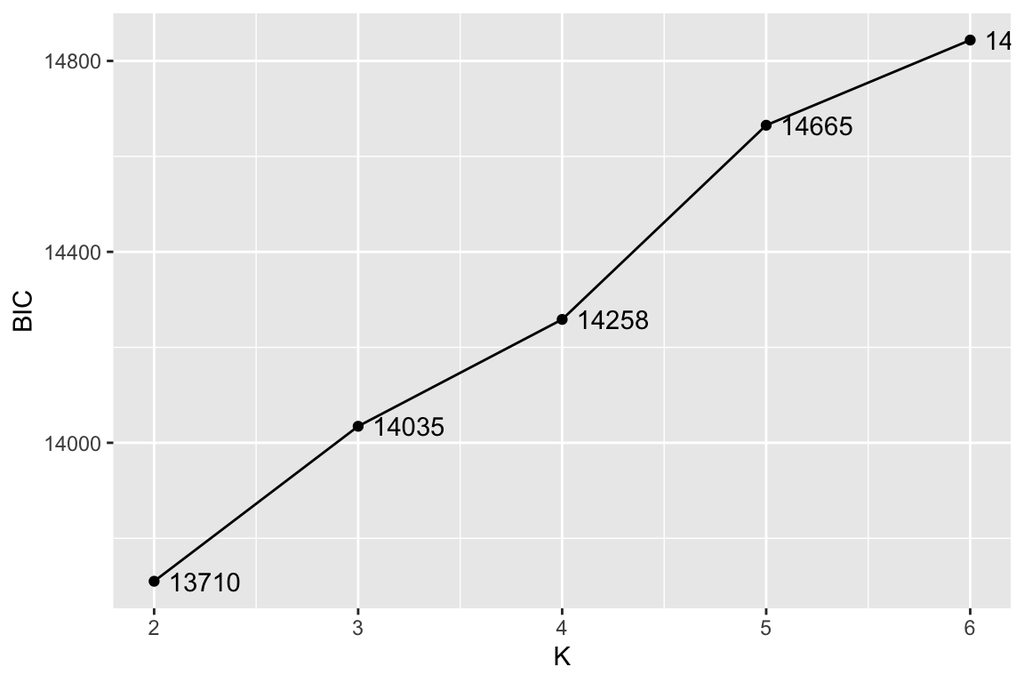

```r
ggplot(data = tune_K$tune_list, aes(x = K, y = BIC, label = round(BIC, 0))) +
  geom_point() +
  geom_line() +
  geom_text(hjust = -0.2)
```

## `fit10` — variable selection for G

> **This example did not run before 3.1.0.** When exactly one exposure survived selection, `lucid()` carried the tuned `Rho_G` into the post-selection refit, where the lasso requires at least two exposures, and the call aborted with `At least 2 exposure variables are needed for variable selection`. The refit on selected features is now unpenalised.

```r
# Variable selection for G
# Add 10 more noise variables to the exposome
noise <- matrix(rnorm(420 * 10), nrow = 420)
exposome_noise <- cbind(exposome, noise)
fit10 <- lucid(G = exposome_noise, Z = methylomics, Y = ck18,
               lucid_model = "early", family = "normal", K = 2,
               Rho_G = RHO_G, seed = 1008)
# Summary of optimal lucid model
# summary(fit10)
```

## `fit11` — variable selection for Z

```r
# Variable selection for Z
# add 10 more noise variables to the methylomics
methylomics_noise <- cbind(methylomics, noise)
fit11 <- lucid(G = exposome, Z = methylomics_noise, Y = ck18,
               lucid_model = "early", family = "normal", K = 2,
               Rho_Z_Mu = RHO_ZMU, Rho_Z_Cov = RHO_ZCOV, seed = 1008)
# Summary of optimal lucid model
# summary(fit11)
```

## `fit12` — joint selection for G and Z

> Also affected by the refit defect above; this example likewise did not complete before 3.1.0.

```r
# Variable selection for G and Z jointly
fit12 <- lucid(G = exposome_noise, Z = methylomics_noise, Y = ck18,
               lucid_model = "early", family = "normal", K = 2,
               Rho_G = 0.01, Rho_Z_Mu = 10, Rho_Z_Cov = 0.5, seed = 123)
```

## `fit13` — high-dimensional Z

```r
# Variable selection for Z (high number of features M)
set.seed(1008)
# Add 200 more noise features to the methylomics
noise <- matrix(rnorm(420 * N_NOISE_HI), nrow = 420)
methylomics_noise <- cbind(methylomics, noise)
fit13 <- lucid(G = exposome, Z = methylomics_noise, Y = ck18,
               family = "normal", lucid_model = "early", K = 2,
               Rho_Z_Mu = 20, Rho_Z_Cov = 0.6)
# Summary of optimal lucid model
# summary(fit13)
```

# 3.4 Deriving confidence intervals

> In 3.1.0 the bootstrap point estimate `t0` is taken from the model you supply rather than from a refit under a fresh random seed, so the `estimate` column below now agrees with `summary(fit1)`. Failed replicates are also counted and warned about instead of being silently dropped.

```r
# Bootstrap to obtain 95% CI (by default) for LUCID
set.seed(123)
boot1 <- boot_lucid(G = exposome, Z = methylomics, Y = ck18,
                    model = fit1, R = BOOT_R)
# 90% CIs
boot2 <- boot_lucid(G = exposome, Z = methylomics, Y = ck18,
                    model = fit1, R = BOOT_R, conf = 0.9)
```

The paper prints this call as `summary(fit1, boot.se = boot1))`, which has an unbalanced closing parenthesis and is a typo in the article. Corrected here:

```r
# Summary table with 95% bootstrap CIs
summary(fit1, boot.se = boot1)
```

```
#>
#> ====================================================
#> LUCID Early Integration: Model Summary
#> ====================================================
#>
#> Model specification
#>   Family                 : normal
#>   Number of observations : 420
#>   Number of clusters (K) : 2
#>
#> Missing-data profile
#>   Listwise missing rows  : 0 / 420 (0.0%)
#>   Sporadic missing rows  : 0 / 420 (0.0%)
#>   Missing cells total    : 0 / 4200 (0.0%)
#>
#> Feature selection overview
#>   G features selected    : 1 / 1 (100.0%)
#>   Z features selected    : 10 / 10 (100.0%)
#>
#> Model fit statistics
#>   Log-likelihood         : -6575.94
#>   BIC                    : 13973.35
#>   Number of parameters   : 136
#>
#> Regularization
#>   Rho_G                  : 0.000
#>   Rho_Z_Mu               : 0.000
#>   Rho_Z_Cov              : 0.000
#>
#> Detailed parameter estimates
#> (1) Y (continuous outcome): cluster 1 mean (intercept), mean differences for other clusters, and covariate effects
#>                  Gamma norm_lower  norm_upper sig
#> (Intercept) -0.5168245 -1.0270215 -0.09295368   *
#> cluster2     1.0466389  0.5315683  1.84469944   *
#>
#> (2) Z: mean of omics data for each latent cluster
#>                          estimate norm_lower norm_upper sig
#> cg_GRHL3.cluster1       0.2347264 -0.5168545  1.2611600
#> cg_BTF3L4.cluster1      0.1786879 -0.7089626  0.9701006
#> cg_AL358472.7.cluster1  0.1859112 -0.2438434  0.7162719
#> cg_HDGF.cluster1        0.1744406 -0.2868099  0.6544868
#> cg_TDRD5.cluster1       0.1909528 -0.3263434  0.8623970
#> cg_CSRNP3.cluster1      0.1677041 -0.4269239  0.7451030
#> cg_HSPD1.cluster1       0.2678372 -0.3776992  0.9446319
#> cg_EPM2AIP1.cluster1   -0.1450411 -0.7947259  0.4033059
#> cg_AC025171.1.cluster1  0.2637637 -0.5454476  1.2914185
#> cg_VTRNA1_3.cluster1   -0.2124714 -0.7920925  0.3377472
#> cg_GRHL3.cluster2      -0.3815671 -1.2124025  0.2990824
#> cg_BTF3L4.cluster2     -0.2946924 -1.0932607  0.3674561
#> cg_AL358472.7.cluster2 -0.3446014 -1.0993389  0.2447584
#> cg_HDGF.cluster2       -0.2659930 -0.8868916  0.2531780
#> cg_TDRD5.cluster2      -0.2319629 -0.8681952  0.3101303
#> cg_CSRNP3.cluster2     -0.1897950 -0.7431123  0.3324304
#> cg_HSPD1.cluster2      -0.3414503 -1.0266286  0.1147991
#> cg_EPM2AIP1.cluster2    0.3128711 -0.2260083  0.8865201
#> cg_AC025171.1.cluster2 -0.2776690 -0.9610466  0.2811105
#> cg_VTRNA1_3.cluster2    0.1905608 -0.3335595  0.8462034
#>
#> (3) E: intercept and odds ratio of being assigned to each latent cluster for each exposure
#>                          estimate norm_lower norm_upper sig
#> hs_hg_m_scaled.cluster2 0.7959118  -2.496156   4.024524
```

# 3.5 Prediction

> **Now matches the paper for the first time.** The article prints `table(pred1$pred.x)` with labels `1` and `2`, but the shipped code returned `0` and `1` in both 3.0.3 and pre-fix 3.1.0. Cluster labels are now `1..K` throughout, consistent with Eq 21, `summary()`, and the `inclusion.p` columns. The counts themselves will differ from the paper’s 223/197.

```r
# Predict cluster with information of Y
pred1 <- predict_lucid(model = fit1, G = exposome, Z = methylomics, Y = ck18)
# Predict cluster without information of Y
pred2 <- predict_lucid(model = fit1, G = exposome, Z = methylomics)
# Predicted cluster label
table(pred1$pred.x)
```

```
#>
#>   1   2
#> 236 184
```

```r
# Predicted outcome
pred1$pred.y[1:5]
```

```
#> [1]  0.2453113 -0.3834012  0.2263823  0.4217217 -0.2095583
```

# 3.6 Incorporating missingness in multi-omics data

Two quirks in the paper’s own setup are reproduced verbatim rather than corrected, so that this section matches the article:

- `arrayInd(sample(1000, 0.1 * 1000), dim(methylomics))` draws from the first 1000 of the 4200 cells in `methylomics`, so the realised sporadic missingness rate is about 2.4%, not the 10% the expression suggests.
- `methylomics_miss_listwise[sample(1:100, 30), ]` selects list-wise rows only from the first 100 of 420 observations.

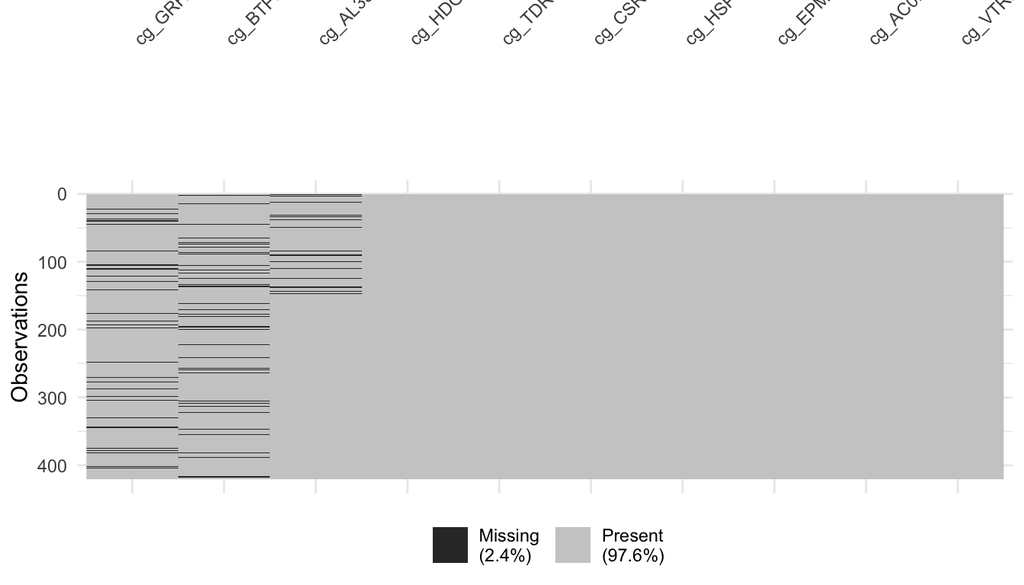

```r
library(visdat)
set.seed(1)
methylomics_miss_sporadic <- methylomics_miss_listwise <- as.matrix(methylomics)
index <- arrayInd(sample(1000, 0.1 * 1000), dim(methylomics))
methylomics_miss_sporadic[index] <- NA # sporadic missing pattern
methylomics_miss_listwise[sample(1:100, 30), ] <- NA # listwise missing pattern
vis_miss(as.data.frame(methylomics_miss_sporadic))
```

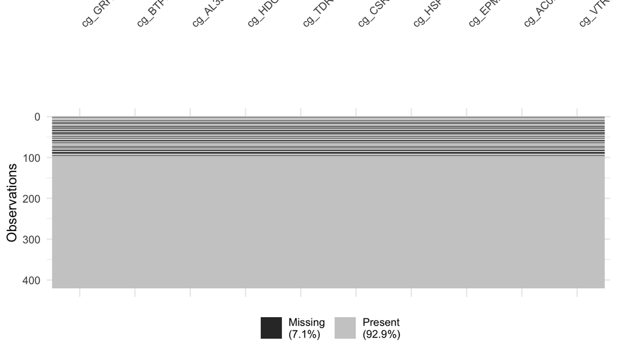

```r
vis_miss(as.data.frame(methylomics_miss_listwise))
```

```r
fit14 <- lucid(G = exposome, Z = methylomics_miss_listwise, Y = ck18,
               lucid_model = "early", K = 2, family = "normal")
fit15 <- lucid(G = exposome, Z = methylomics_miss_sporadic, Y = ck18,
               lucid_model = "early", K = 2, family = "normal")
# summary(fit15)
```

A check the paper does not perform — that list-wise rows are returned as `NA` rather than filled with fabricated values, and that observed cells are never altered:

```r
lw <- which(rowSums(is.na(methylomics_miss_listwise)) == ncol(methylomics_miss_listwise))
cat("list-wise rows still NA in fit14$Z:      ", all(is.na(fit14$Z[lw, ])), "\n")
```

```
#> list-wise rows still NA in fit14$Z:       TRUE
```

```r
obs <- !is.na(methylomics_miss_sporadic)
cat("observed cells unchanged in fit15$Z:     ",
    isTRUE(all.equal(fit15$Z[obs], methylomics_miss_sporadic[obs])), "\n")
```

```
#> observed cells unchanged in fit15$Z:      TRUE
```

```r
cat("sporadic cells imputed and finite:       ",
    all(is.finite(fit15$Z[!obs])), "\n")
```

```
#> sporadic cells imputed and finite:        TRUE
```

# 3.7 LUCID in Parallel

> `summary(fit)$BIC` now resolves for parallel and serial models; it was previously an early-model-only field that returned `NULL` elsewhere.

```r
# Create a list of multi-omics data
omics_lst <- simulated_data[-which(names(simulated_data) == "phenotype")]
Z = omics_lst[c(1:3)]
# LUCID in parallel, adjusting for the covariates for the E-X and X-Y associations
fit16 <- lucid(G = exposome, Z = Z, Y = ck18, K = list(2, 2, 2), family = "normal",
               CoY = covs, CoG = covs,
               lucid_model = "parallel", useY = TRUE)
# print the summary of the LUCID in parallel model
summary(fit16)
```

```
#>
#> ====================================================
#> LUCID Parallel: Model Summary
#> ====================================================
#>
#> Model specification
#>   Family                 : gaussian
#>   Number of observations : 420
#>   Clusters per layer     : 2, 2, 2
#>
#> Missing-data profile by layer
#>   Layer 1 listwise rows : 0 / 420 (0.0%)
#>   Layer 1 sporadic rows : 0 / 420 (0.0%)
#>   Layer 1 missing cells : 0 / 4200 (0.0%)
#>   Layer 2 listwise rows : 0 / 420 (0.0%)
#>   Layer 2 sporadic rows : 0 / 420 (0.0%)
#>   Layer 2 missing cells : 0 / 4200 (0.0%)
#>   Layer 3 listwise rows : 0 / 420 (0.0%)
#>   Layer 3 sporadic rows : 0 / 420 (0.0%)
#>   Layer 3 missing cells : 0 / 4200 (0.0%)
#>
#> Feature selection overview
#>   G features selected    : 1 / 1 (100.0%)
#>   G features by layer
#>     Layer 1              : 1 / 1 (100.0%)
#>     Layer 2              : 1 / 1 (100.0%)
#>     Layer 3              : 1 / 1 (100.0%)
#>   Z features
#>     Layer 1 selected     : 10 / 10 (100.0%)
#>     Layer 1 multi-cluster: 10
#>     Layer 2 selected     : 10 / 10 (100.0%)
#>     Layer 2 multi-cluster: 10
#>     Layer 3 selected     : 10 / 10 (100.0%)
#>     Layer 3 multi-cluster: 10
#>
#> Model fit statistics
#>   Log-likelihood         : -16169.04
#>   BIC                    : 34808.55
#>   Number of parameters   : 409
#>
```

[output cut: 61 more lines]

```
#>                              beta        OR
#> (Intercept).cluster2    2.4308007 11.367981
#> hs_hg_m_scaled.cluster2 0.9694861  2.636589
#>
#> Layer 2
#>
#>                               beta       OR
#> (Intercept).cluster2    -1.0848810 0.337942
#> hs_hg_m_scaled.cluster2  0.4478715 1.564978
#>
#> Layer 3
#>
#>                               beta        OR
#> (Intercept).cluster2    -0.1489437 0.8616176
#> hs_hg_m_scaled.cluster2 -0.0522552 0.9490866
```

Beyond the paper text: `fit16`’s object structure. Two fields differ from `fit1` above – `N` (sample size) is present here but not for early, and `z` (the joint E-step responsibility array across layers, before it is marginalized into `inclusion.p`) appears only for parallel.

```r
names(fit16)
```

```
#>  [1] "res_Beta"             "res_Mu"               "res_Sigma"
#>  [4] "res_Gamma"            "K"                    "N"
#>  [7] "var.names"            "init_omic.data.model" "likelihood"
#> [10] "inclusion.p"          "family"               "select"
#> [13] "useY"                 "Z"                    "z"
#> [16] "init_impute"          "init_par"             "Rho"
#> [19] "missing_summary"      "em_control"
```

```r
# LUCID in parallel, tune for the number of clusters for methylomics
fit17 <- lucid(G = exposome, Z = Z, Y = ck18, K = list(2, 2:3, 2), family = "normal",
               lucid_model = "parallel", useY = TRUE)
# summary(fit17)
```

# 3.8 LUCID in Serial

```r
# LUCID in serial, adjusting for the covariates of the E-X and X-Y associations
# Tune the number of clusters for methylome and transcriptome
# All 3 sub-models are LUCID early integration models and each with two latent
# clusters for each layer
fit18 <- lucid(G = exposome, Z = Z, Y = ck18,
               lucid_model = "serial", CoY = covs, CoG = covs,
               K = list(2:3, 2:3, 2), useY = TRUE, family = "normal")
# Print the summary of the LUCID in serial model
summary(fit18)
```

```
#>
#> ====================================================
#> LUCID Serial: Model Summary
#> ====================================================
#>
#> Model specification
#>   Family                 : normal
#>   Number of observations : 420
#>   Number of stages       : 3
#>   Stage 1               : early (K = 2)
#>   Stage 2               : early (K = 2)
#>   Stage 3               : early (K = 2)
#>
#> Missing-data profile by stage
#>   Stage 1
#>     Listwise rows         : 0
#>     Sporadic rows         : 0
#>   Stage 2
#>     Listwise rows         : 0
#>     Sporadic rows         : 0
#>   Stage 3
#>     Listwise rows         : 0
#>     Sporadic rows         : 0
#>
#> Model fit statistics
#>   Log-likelihood         : -16192.84
#>   BIC                    : 34825.94
#>
#> Regularization
#>   Rho_G                  : 0.000
#>   Rho_Z_Mu               : 0.000
#>   Rho_Z_Cov              : 0.000
#>
#> Stage-wise detailed parameter estimates
#>
#> --- Stage 1 (early) ---
#>
#> ====================================================
#> LUCID Early Integration: Model Summary
#> ====================================================
```

[output cut: 135 more lines]

```
#> miR.101.3p     0.107122761  0.021317094
#> miR.125a.5p    0.017187868  0.004999402
#> miR.125b.1.3p -0.040943999  0.091728548
#> miR.127.3p    -0.073929952  0.203206406
#> miR.140.5p     0.452113287 -0.143596886
#> miR.142.3p     0.032825873  0.028318527
#> miR.144.5p     0.151175466 -0.066846589
#> miR.19a.3p    -0.009038789  0.058957652
#> miR.19b.3p     0.092096746  0.026344853
#> miR.21.5p      0.090410399  0.007634008
#>
#> (3) E: intercept and odds ratio of being assigned to each latent cluster for each cluster from previous serial stage
#>                               beta       OR
#> (Intercept).cluster2     0.1300760 1.138915
#> Stage2.cluster2.cluster2 0.7566204 2.131062
```

Beyond the paper text: `fit18`’s object structure. Serial adds `submodel` (the fitted stage models, each a complete `early_lucid`/`lucid_parallel` object) and `res_Delta` (between-stage transition coefficients). `likelihood` and `select` are present, same as early/parallel, but are aggregates over stages: `likelihood` sums each stage’s own log-likelihood (a serial chain has no single joint EM loop to report one from), and `select` is stage 1’s own selection only – the one stage whose `G` is the cohort’s real exposures, not a previous stage’s cluster probabilities.

```r
names(fit18)
```

```
#>  [1] "res_Beta"             "res_Mu"               "res_Sigma"
#>  [4] "res_Delta"            "res_Gamma"            "K"
#>  [7] "N"                    "var.names"            "init_omic.data.model"
#> [10] "inclusion.p"          "family"               "useY"
#> [13] "Z"                    "init_impute"          "init_par"
#> [16] "submodel"             "missing_summary"      "Rho"
#> [19] "em_control"           "likelihood"           "select"
```

```r
cat("top-level likelihood (sum over stages):", fit18$likelihood, "\n")
```

```
#> top-level likelihood (sum over stages): -16192.84
```

```r
cat("top-level select is stage 1's select:",
    identical(fit18$select, fit18$submodel[[1]]$select), "\n")
```

```
#> top-level select is stage 1's select: TRUE
```

```r
# LUCID in serial with the first sub-model being LUCID in parallel
# and the second sub-model being LUCID early integration
# Rearrange the omics list to match the new structure of the LUCID in serial model
Z_new = list(list(omics_lst$methylome, omics_lst$transcriptome), omics_lst$miRNA)
# Fit the LUCID in serial model with the new omics list and the new K list
fit19 <- lucid(G = exposome, Z = Z_new, Y = ck18,
               lucid_model = "serial", CoY = covs, CoG = covs,
               K = list(list(2, 2), 2), useY = TRUE, family = "normal")
# summary(fit19)
```

# Status of every example

| section | example | expected | got | status |
| --- | --- | --- | --- | --- |
| 3.1 fitting | fit1 | early_lucid | early_lucid | ran |
| 3.1 fitting | fit2 | early_lucid | early_lucid | ran |
| 3.1 initialisation | fit3.1 | early_lucid | early_lucid | ran |
| 3.1 initialisation | fit3.2 | early_lucid | early_lucid | ran |
| 3.1 initialisation | fit4 | early_lucid | early_lucid | ran |
| 3.1 unsupervised | fit5 | early_lucid | early_lucid | ran |
| 3.1 covariates | fit6 | early_lucid | early_lucid | ran |
| 3.1 covariates | fit7 | early_lucid | early_lucid | ran |
| 3.2 interpretation | summary(fit1) | call | - | ran |
| 3.2 interpretation | plot(fit1) | call | - | ran |
| 3.2 interpretation | plot(fit1, G_color=) | call | - | ran |
| 3.2 interpretation | plot(fit1, link colors) | call | - | ran |
| 3.3 model selection | fit8 | early_lucid | early_lucid | ran |
| 3.3 model selection | tune_K | list | list | ran |
| 3.3 model selection | fit9 | early_lucid | early_lucid | ran |
| 3.3 variable selection | fit10 | early_lucid | early_lucid | ran |
| 3.3 variable selection | fit11 | early_lucid | early_lucid | ran |
| 3.3 variable selection | fit12 | early_lucid | early_lucid | ran |
| 3.3 variable selection | fit13 | early_lucid | early_lucid | ran |
| 3.4 inference | boot1 | list | list | ran |
| 3.4 inference | boot2 | list | list | ran |
| 3.4 inference | summary(fit1, boot.se = boot1) | call | - | ran |
| 3.5 prediction | pred1 | list | list | ran |
| 3.5 prediction | pred2 | list | list | ran |
| 3.6 missing data | fit14 | early_lucid | early_lucid | ran |
| 3.6 missing data | fit15 | early_lucid | early_lucid | ran |
| 3.7 parallel | fit16 | lucid_parallel | lucid_parallel | ran |
| 3.7 parallel | fit17 | lucid_parallel | lucid_parallel | ran |
| 3.7 parallel | summary(fit16) | call | - | ran |
| 3.8 serial | fit18 | lucid_serial | lucid_serial | ran |
| 3.8 serial | fit19 | lucid_serial | lucid_serial | ran |
| 3.8 serial | summary(fit18) | call | - | ran |

```
#> 32 of 32 examples ran; 0 errored.
```

```
#>
#> Total knit time: 14.9 minutes (full_grid = TRUE)
```

# Spot checks against known-correct values

Invariants established independently of the paper (see `NEWS.md`):

| check | observed | expected | ok |
| --- | --- | --- | --- |
| fit1 log-likelihood | -6575.94 | -6575.89 | TRUE |
| fit1 number of parameters | 136 | 136 | TRUE |
| fit8 selected K | 2 | 2 | TRUE |
| pred.x labels are 1..K | 1,2 | 1,2 | TRUE |
| fit1 converged | TRUE | TRUE | TRUE |